# Walkthrough 2

Matthew Biggs

#### The objectives of Project 2 include:

- Find or generate data set
- Create GitHub repository
- Wrangle the data using Dplyr
- Perform at least one table join
- Produce two figures
- Communicate results

Follows is an example project that meets these objectives.

#### Find or generate data set

For this project, you can start to branch out and look for interesting data sets anywhere! Here are a few places to start looking, and by all means, get creative:

- [FiveThirtyEight](https://data.fivethirtyeight.com/) publishes many of the data sets from their articles.
- [UCI Machine Learning Repository](https://archive.ics.uci.edu/ml/datasets.html)
- Open data from the cities of [Chapel Hill](https://www.chapelhillopendata.org/page/home1/), [Durham](https://opendurham.nc.gov/pages/home/), and [Raleigh](https://data.raleighnc.gov/)
- [United Nations Data](http://data.un.org/)
- [National Institutes of Health Data](https://exporter.nih.gov/ExPORTER_Catalog.aspx)
- [New York Times Data](https://developer.nytimes.com/)
- [US Department of Agriculture](https://developer.nytimes.com/)

You get the idea…there is a TON of data out there. Take time to find a data set that interests you personally. Find a data set that can help answer questions you have about the world.

Another option is to generate your own data! This could take the form of [a survey](https://www.surveymonkey.com/) you send out to your friends. You can simulate a favorite game and [deduce winning strategies](http://eatsgraphsandleaves.blogspot.com/2015/12/ggplot-in-python.html). You can approach a local business and ask for sales data. This is your project! Make it interesting!

The only constraint: the data needs to exists as files in your GitHub repo, and you need to read it into your script. For example, in this walkthrough I chose two data sets from FiveThirtyEight: congress-terms and librarians-by-msa. I saved both as CSV files and read them into an Rscript like so:

```r
library(tidyverse)

congress = read.csv('data/congress-terms.csv', sep=',', header=TRUE,
                    colClasses=c('integer','factor','character','character','character','character','character','Date','character','factor','factor','Date','numeric'))
congress_t = as_tibble(congress)

librarians = read.csv('data/librarians-by-msa.csv', sep=',', header=TRUE, na.strings='**',
                      colClasses=c('character','character','numeric','numeric','numeric','numeric'))
librarians_t = as_tibble(librarians)
```

#### Create GitHub repository

You know the drill…

#### Wrangle the data using Dplyr

In this case, I only keep the most recent congress (the 113th), using the `filter` command. For the librarians data set, I take an average job quotient (number of librarians per 1000 people) for the state.

```r
recent_congress =  congress_t %>%
  filter(congress == max(congress_t$congress))

librarians_ave = librarians_t %>%
  rename(state = prim_state) %>%
  group_by(state) %>%
  summarise(ave_jobs_1000 = mean(jobs_1000))
```

#### Perform at least one table join

```r
congress_librarians = inner_join(recent_congress, librarians_ave, by='state' )
```

#### Produce two figures

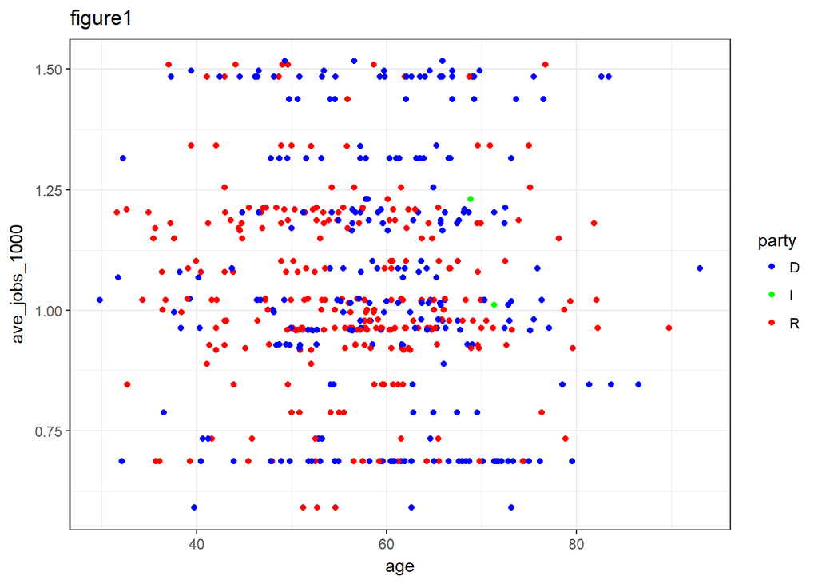

```r
ggplot(data = congress_librarians, mapping = aes(x=age, y=ave_jobs_1000, color=party)) +
  geom_point() +
  scale_color_manual(values=c("blue","green","red")) +
  ggtitle('figure1') +
  theme_bw()
```

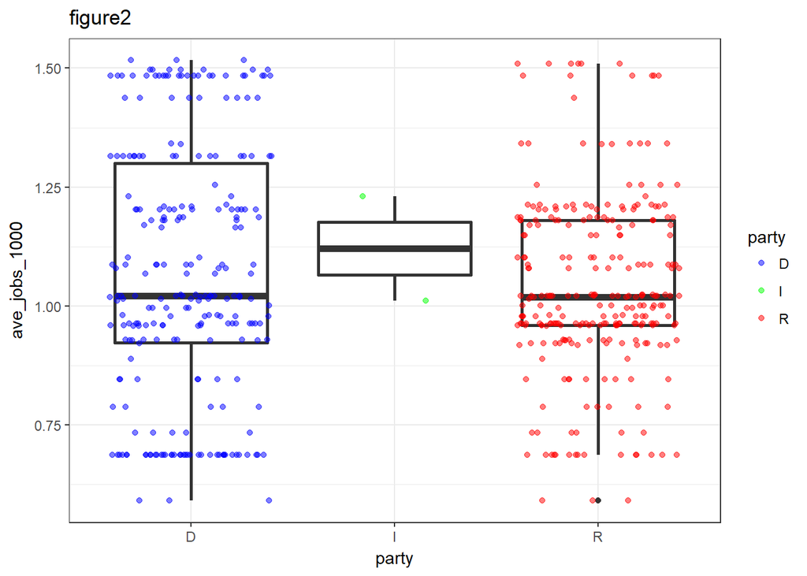

```r
ggplot(data = congress_librarians, mapping = aes(x=party, y=ave_jobs_1000)) +
  geom_boxplot(size=1) +
  geom_jitter(alpha=0.5, mapping = aes(color=party)) +
  scale_color_manual(values=c("blue","green","red")) +
  ggtitle('figure2') +
  theme_bw()
```

#### Communicate results

```r
ave_jobs_D = congress_librarians %>%
  filter(party == 'D') %>%
  select(ave_jobs_1000)

ave_jobs_R = congress_librarians %>%
  filter(party == 'R') %>%
  select(ave_jobs_1000)

wt = wilcox.test(ave_jobs_R$ave_jobs_1000,ave_jobs_D$ave_jobs_1000)
```